# ProgramExamples

# Demography

```r
tab1 <- utable(sysbp2~sysbp+sex+age+diabetes+heartrte+educ+totchol+prevmi,data=Fram1)
publish(tab1)
```

```
##  Variable     Level above (n=2156) below (n=2278) Total (n=4434) p-value
##     sysbp mean (sd)       15 (1.9)     11.6 (0.9)     13.3 (2.2) <0.0001
##       sex      Male     944 (43.8)   1,000 (43.9)   1,944 (43.8)
##              Female    1212 (56.2)    1278 (56.1)   2,490 (56.2)  0.9635
##       age mean (sd)      5.3 (0.8)      4.7 (0.8)        5 (0.9) <0.0001
##  diabetes         0   2,066 (95.8)   2,247 (98.6)   4,313 (97.3)
##                   1       90 (4.2)       31 (1.4)      121 (2.7) <0.0001
##  heartrte mean (sd)    77.8 (12.7)      74 (11.2)    75.9 (12.1) <0.0001
##             missing              1              0              1
##      educ         1   1,004 (47.8)     818 (36.8)   1,822 (42.2)
##                   2     597 (28.4)     684 (30.8)   1,281 (29.6)
##                   3     295 (14.0)     421 (19.0)     716 (16.6)
##                   4      205 (9.8)     297 (13.4)     502 (11.6) <0.0001
##             missing             55             58            113
##   totchol mean (sd)   245.4 (45.5)     229 (42.3)     237 (44.7) <0.0001
##             missing             23             29             52
##    prevmi         0   2,108 (97.8)   2,240 (98.3)   4,348 (98.1)
##                   1       48 (2.2)       38 (1.7)       86 (1.9)  0.2156
```

```r
# to export to excell, use the following:
write.csv2(summary(tab1),file="tab1.csv")
```

# Basic Cox model with focus on Blood pressure

```r
# Missing values not good for analysis
Fram1 <- Fram1[complete.cases(Fram1),]
fit <- coxph(Surv(timedth,death)~sysbp+sex+age+diabetes+heartrte+educ+totchol+prevmi,data=Fram1)
summary(fit) # Fast and primitive
```

```
## Call:
## coxph(formula = Surv(timedth, death) ~ sysbp + sex + age + diabetes +
##     heartrte + educ + totchol + prevmi, data = Fram1)
##
##   n= 4269, number of events= 1491
##
##                 coef  exp(coef)   se(coef)       z           Pr(>|z|)
## sysbp      0.1378547  1.1478088  0.0114603  12.029            < 2e-16 ***
## sexFemale -0.7222888  0.4856394  0.0552264 -13.079            < 2e-16 ***
## age        0.7771037  2.1751632  0.0356637  21.790            < 2e-16 ***
## diabetes1  0.8047487  2.2361345  0.1096476   7.339 0.0000000000002145 ***
## heartrte   0.0050120  1.0050246  0.0021237   2.360            0.01828 *
## educ2      0.0213421  1.0215715  0.0650052   0.328            0.74267
## educ3     -0.1071730  0.8983702  0.0789484  -1.358            0.17462
## educ4     -0.2706107  0.7629134  0.0931257  -2.906            0.00366 **
## totchol    0.0003767  1.0003768  0.0006194   0.608            0.54308
## prevmi1    0.9691448  2.6356895  0.1267997   7.643 0.0000000000000212 ***
## ---
## Signif. codes:  0 '***' 0.001 '**' 0.01 '*' 0.05 '.' 0.1 ' ' 1
##
##           exp(coef) exp(-coef) lower .95 upper .95
## sysbp        1.1478     0.8712    1.1223    1.1739
## sexFemale    0.4856     2.0591    0.4358    0.5412
## age          2.1752     0.4597    2.0283    2.3326
## diabetes1    2.2361     0.4472    1.8037    2.7722
## heartrte     1.0050     0.9950    1.0008    1.0092
## educ2        1.0216     0.9789    0.8994    1.1604
## educ3        0.8984     1.1131    0.7696    1.0487
## educ4        0.7629     1.3108    0.6356    0.9157
## totchol      1.0004     0.9996    0.9992    1.0016
## prevmi1      2.6357     0.3794    2.0557    3.3793
##
## Concordance= 0.743  (se = 0.008 )
## Rsquare= 0.255   (max possible= 0.997 )
## Likelihood ratio test= 1254  on 10 df,   p=<2e-16
## Wald test            = 1248  on 10 df,   p=<2e-16
## Score (logrank) test = 1421  on 10 df,   p=<2e-16
```

## Assumptions for Cox

Model assumptions (proportional hazards, absence of interaction, linearity) are difficult to assess with a formal statistical test because the order of assessment matters and because in large data sets even small deviations are significant whereas in small data sets even groft deviations can be insignificant.

Useful investigation of the proportional hazard assumptions of the model:

- Stop time by artificially censoring and compare beta coefficients with full followup
- Stratify the baseline hazard for categorical variables
- Use timereg package’s martingal residual plots

Test of linearity for sysbp: Does it increase information to add a restricted cubic spline of sysbp?

```r
fit2 <- coxph(Surv(timedth,death)~sysbp+rcs(sysbp)+sex+age+diabetes+heartrte+educ+totchol+prevmi,data=Fram1)
anova(fit, fit2, test = "Chisq")
```

```
## Analysis of Deviance Table
##  Cox model: response is  Surv(timedth, death)
##  Model 1: ~ sysbp + sex + age + diabetes + heartrte + educ + totchol + prevmi
##  Model 2: ~ sysbp + rcs(sysbp) + sex + age + diabetes + heartrte + educ + totchol + prevmi
##   loglik  Chisq Df P(>|Chi|)
## 1 -11539
## 2 -11536 6.4229  3   0.09275 .
## ---
## Signif. codes:  0 '***' 0.001 '**' 0.01 '*' 0.05 '.' 0.1 ' ' 1
```

## Nice table output

```r
reg <- summary(regressionTable(fit))$rawTable
```

```
##    Variable  Units HazardRatio       CI.95   p-value
## 1     sysbp               1.15 [1.12;1.17]   < 0.001
## 2       sex   Male         Ref
## 3           Female        0.49 [0.44;0.54]   < 0.001
## 4       age               2.18 [2.03;2.33]   < 0.001
## 5  diabetes      0         Ref
## 6                1        2.24 [1.80;2.77]   < 0.001
## 7  heartrte               1.01 [1.00;1.01]   0.01828
## 8      educ      1         Ref
## 9                2        1.02 [0.90;1.16]   0.74267
## 10               3        0.90 [0.77;1.05]   0.17462
## 11               4        0.76 [0.64;0.92]   0.00366
## 12  totchol               1.00 [1.00;1.00]   0.54308
## 13   prevmi      0         Ref
## 14               1        2.64 [2.06;3.38]   < 0.001
```

```r
reg <- summary(regressionTable(fit,factor.reference='inline'))$rawTable
```

```
##    Variable          Units HazardRatio       CI.95   p-value
## 1     sysbp                       1.15 [1.12;1.17]   < 0.001
## 2       sex Female vs Male        0.49 [0.44;0.54]   < 0.001
## 3       age                       2.18 [2.03;2.33]   < 0.001
## 4  diabetes         1 vs 0        2.24 [1.80;2.77]   < 0.001
## 5  heartrte                       1.01 [1.00;1.01]   0.01828
## 6      educ         2 vs 1        1.02 [0.90;1.16]   0.74267
## 7                   3 vs 1        0.90 [0.77;1.05]   0.17462
## 8                   4 vs 1        0.76 [0.64;0.92]   0.00366
## 9   totchol                       1.00 [1.00;1.00]   0.54308
## 10   prevmi         1 vs 0        2.64 [2.06;3.38]   < 0.001
```

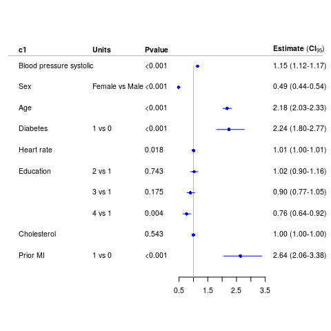

```r
# Add a column of relevant variable explanations
c1 <- c("Blood pressure systolic","Sex","Age","Diabetes","Heart rate","Education","","","Cholesterol",
       "Prior MI")
reg <- cbind(c1,reg)
# Nice format of p
reg$Pvalue <- format.pval(reg$Pvalue,eps=0.001,digits = 3)
plotConfidence(x=reg[,c(4:6)],labels=reg[,c(1,3,7)])
```

```r
dev.off() # Maybe not necessary, but resets graphic parameters
```

# Competing risk

Analysis to time to cvd - with and without competing risk of death from other causes

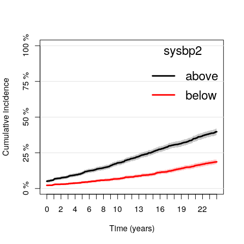

```r
fit2 <- prodlim(Hist(timecvd,cvd)~sysbp2,data=Fram1)
plot(fit2,type="cuminc",timeconverter = "days2years",atrisk=FALSE,cex=0.5)
```

```r
# Problem: Cumulative incidence is not a probability

#Recode cvd to have competing risk of death=2
table(Fram1$cvd,Fram1$death) # Cross table prior to change
```

```
##
##        0    1
##   0 2399  756
##   1  379  735
```

```r
Fram1[death==1 & cvd !=1, ':='(cvd=2, timecvd=timedth) ]
table(Fram1$cvd,Fram1$death) # Cross table after change
```

```
##
##        0    1
##   0 2399    0
##   1  379  735
##   2    0  756
```

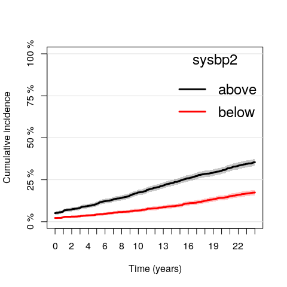

```r
fit3 <- prodlim(Hist(timecvd,cvd)~sysbp2,data=Fram1) #with competing risk
plot(fit3,type="cuminc",timeconverter = "days2years",atrisk=FALSE,cex=0.5)
```

```r
dev.off() # Maybe not necessary, but resets graphic parameters
```

## Cox for cvd

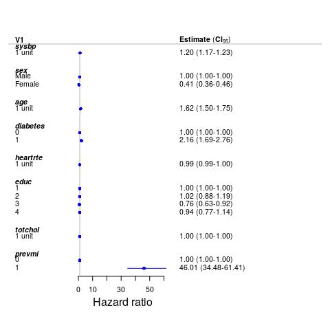

```r
fit4 <- coxph(Surv(timecvd,cvd==1)~sysbp+sex+age+diabetes+heartrte+
                    educ+totchol+prevmi,data=Fram1)
fit4 <- regressionTable(fit4)
plot(fit4)
```

```r
dev.off() # Maybe not necessary, but resets graphic parameters
```

# Prediction

So what is sysbp worth for prediction?

## Models for cvd with and without sysbp

```r
fit_sbp <- CSC(Hist(timecvd,cvd)~sysbp+sex+age+diabetes+heartrte+
                educ+totchol+prevmi,data=Fram1)
fit_nsbp <- CSC(Hist(timecvd,cvd)~sex+age+diabetes+heartrte+
                 educ+totchol+prevmi,data=Fram1)
# Score for difference
fit_dif <- Score(list("+sbp"=fit_sbp,"-sbp"=fit_nsbp),
          formula=Hist(timecvd,cvd)~sysbp+sex+age+diabetes+heartrte+
            educ+totchol+prevmi, data=Fram1,times=10*365,nullModel = FALSE,
          plots = "ROC",summary="riskQuantile")
fit_dif
```

```
##
## Summary statistics riskQuantile:
## $score
##    model times      cause         Q.0       Q.25       Q.50      Q.75
## 1:  +sbp  3650    overall 0.008410072 0.04226003 0.07910307 0.1399264
## 2:  -sbp  3650    overall 0.014075090 0.04977595 0.08575558 0.1396554
## 3:  +sbp  3650          1 0.008410072 0.11142200 0.18409328 0.3480714
## 4:  +sbp  3650          2 0.008410072 0.06100280 0.12700161 0.2118607
## 5:  -sbp  3650          1 0.014075090 0.10352671 0.15772763 0.2649321
## 6:  -sbp  3650          2 0.014075090 0.07693827 0.11876833 0.1778291
## 7:  +sbp  3650 event-free 0.008410072 0.03711906 0.07025723 0.1166569
## 8:  -sbp  3650 event-free 0.014075090 0.04510067 0.07581686 0.1230823
##        Q.100
## 1: 1.2248912
## 2: 1.1694024
## 3: 1.2248912
## 4: 1.1106779
## 5: 1.1694024
## 6: 1.1280635
## 7: 0.9066272
## 8: 0.9131965
##
## $contrasts
##    reference model times      cause       Q.0         Q.25         Q.50
## 1:      +sbp  -sbp  3650    overall -0.643834 -0.008698155  0.006929335
## 2:      +sbp  -sbp  3650          1 -0.643834 -0.043159038 -0.002479881
## 3:      +sbp  -sbp  3650          2 -0.643834 -0.044969465  0.005280621
## 4:      +sbp  -sbp  3650 event-free -0.643834 -0.004738850  0.007404711
##          Q.75     Q.100
## 1: 0.01931406 0.2834715
## 2: 0.01714627 0.2834715
## 3: 0.02349801 0.2834715
## 4: 0.01937315 0.1791609
##
## $metrics
## [1] "riskQuantile"
##
## attr(,"class")
## [1] "scoreriskQuantile"
##
```

[output cut: 12 more lines]

```
##
## Metric Brier:
##
## Results by model:
##
##    model times  Brier      se se.conservative  lower  upper
## 1:  +sbp  3650 0.0813 0.00777         0.00321 0.0661 0.0965
## 2:  -sbp  3650 0.0843 0.00806         0.00333 0.0685 0.1001
##
## Results of model comparisons:
##
##    times model reference delta.Brier      se    lower   upper      p
## 1:  3650  -sbp      +sbp     0.00298 0.00141 0.000218 0.00573 0.0344
##
## Data for ROC plot are stored in the object as x[["ROC"]].
```

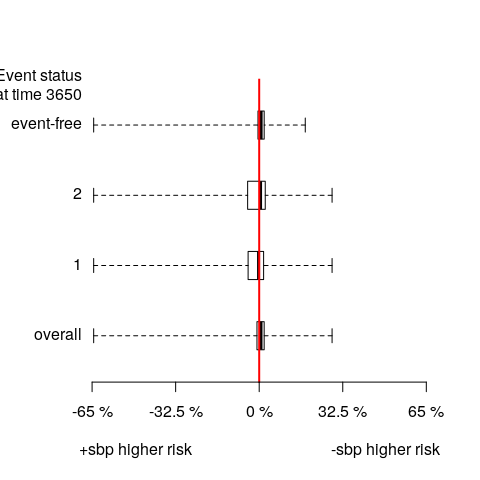

```r
boxplot(fit_dif) # Gennemsnitlig forskel for grupper
```

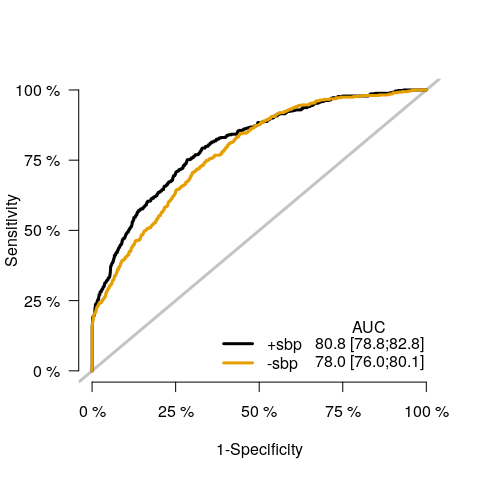

```r
plotROC(fit_dif) # ROC kurve
```

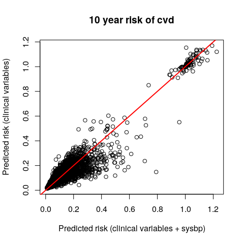

```r
# Plot of individual prediction with and without sysbp
Pred_with_sysbp <- predict(fit_sbp, times=10*365,newdata=Fram1,cause=1)
Pred_without_sysbp <- predict(fit_nsbp, times=10*365,newdata=Fram1,cause=1)

plot(Pred_with_sysbp$absRisk,Pred_without_sysbp$absRisk,
     main="10 year risk of cvd",
     xlab="Predicted risk (clinical variables + sysbp)",
     ylab="Predicted risk (clinical variables)")
abline(0,1,col="red",lwd=2)
```

```r
dev.off() # Maybe not necessary, but resets graphic parameters
```

# Matching

Prepare to match on diabetes

```r
#Find date of first occurrence of diabetes
diab <- Framingham[diabetes==1,c("randid","time","diabetes")]
diab <- diab[,.SD[1],by=randid]
setnames(diab,c("time","diabetes"),c("timediab","diabetestime"))

Fram1 <- Framingham[,.SD,.SDcols=c("randid","time","sysbp","sex","age","diabetes","heartrte","educ",
                              "totchol","prevmi","timedth","death","timecvd","cvd")]
Fram1 <- Fram1[,.SD[1],by="randid"]
Fram1 <- merge(Fram1,diab,by="randid",all=TRUE)
Fram1[is.na(diabetestime),diabetestime:=0]
# for exact matching continuous variables needs to ba sutiably rounded
Fram1[,age_kat:=round(age/5)]
```

Matching on sex, age (5 year) and prior cvd Combines matching on fixe parameters with requirement of controls to be alive at time of matching. Further, it is required to match on the time dependent variable cvd

```r
# Risk set matching with reuse of cases (control prior to case) and reuse of
# controls - more cases get controls
Fram1 <- Fram1[complete.cases(Fram1)]
Match <- riskSetMatch("randid","diabetestime",c("age_kat","sex"),Fram1,2,caseIndex=
                       "timediab",controlIndex="timedth",dateterms = "timecvd",
                     ,reuseCases=TRUE,reuseControls=TRUE)
matchReport(Match,"randid","diabetestime","caseid")
```

```
##
##  ------------------------------------------------------------------
##  Matching success
##  Line 1, number of controls found - Line 2, number of occurrencescontrols
##   1   2
##   9 317
##
##  ------------------------------------------------------------------
##  Reuse/use of controls
##  Line 1, number of times - Line 2, number of occurrences
## N
##   1   2   3   4   5
##  72 132  78  17   1
##
##  ------------------------------------------------------------------
##  Use and reuse of cases as controls
##  Line 1, number of times - Line 2, number of occurrences
## N
##   1   2   3   4   5   6
##  26  72 132  78  17   1
##
##  ------------------------------------------------------------------
```

```r
# Cox model
fit <- coxph(Surv(timediab,timedth,death)~diabetestime+strata(caseid),data=Match)
summary(regressionTable(fit))
```

```
##       Variable Units HazardRatio       CI.95  p-value
## 1 diabetestime              1.20 [0.99;1.45]   0.0692
```

[output not shown]

# Time dependent analysis

Prepare data for time dependent analysis

```r
# Limited basic dataset fraom Framinham with firt record for each randid - and just some variable
setkeyv(Framingham,c("randid","time"))
Fram2 <- Framingham[,.SD[1],by="randid",
  .SDcols=c("time","sex","age","educ","timedth","death")]
Fram2[,':='(inn=time,out=timedth)] # new variables for intervals - to avoid confusion
# Comorbidities
# Diabetes as time dependent variable:
diab <- Framingham[diabetes==1,c("randid","time")]
diab <- diab[,.SD[1],by="randid"]
setnames(diab,"time","diabetes") # changes name of time to "diabetes"
# cvd as time dependent variable
cvd <- Framingham[cvd==1,c("randid","timecvd")]
cvd <- cvd[,.SD[1],by="randid"]
setnames(cvd,"timecvd","cvd")
# Combine the chosen comorbidites in a matrix like data.table where the first column
# is ID and following columns dates of time dependent comorbidites
comorb <- merge(diab,cvd,by="randid",all=TRUE)
# if there are multiple dataset, the following allows multiple merges in one step:
#comorb <-Reduce(function(x, y) merge(x, y,by="randid", all=TRUE), list(diab,cvd))

# Periodic variables
# Create a data.table with columns defining ID, start-period, end-period, a value for period,
# and name of the period variable.
Periods <- read.csv(text="randid,start,end,value,name") #Make empty data.frame
setDT(Periods)
for (var in c("sysbp","heartrte","totchol")){
  temp <- Framingham[,.SD,.SDcols=c("randid","time",var,"timedth")]
  temp[,end:=shift(time,type="lead"),by=randid]
  temp[is.na(end),end:=timedth]
  temp[,timedth:=NULL]
  setnames(temp,c("time",var),c("start","value"))
  temp[,name:=var]
  Periods <- rbind(Periods,temp) # Add the next period sequence to the output data
}
Periods[,end:=as.integer(end)]
```

With the data prepared a time dependent analysis can be performed. Both Cox and Poisson are possible, but the Cox-regression is very slow and therefore left as a comment.

```r
#tFram2 <- Fram2[randid==2448]
#Periods[,value:=as.character(value)]
# Split by comorbidities
Fram2 <- lexisTwo(Fram2,comorb,c("randid","inn","out","death")
                  ,c("diabetes","cvd"))
F#Split on variables with periods
```

```
## [1] FALSE
```

```r
Fram2 <- lexisFromTo(Fram2,Periods,c("randid","inn","out","death"),
                     c("randid","start","end","value","name"))
#Split on age
Fram2[,birth:=-age*365.25]
Fram2 <- lexisSeq(Fram2,c("randid","inn","out","death"),varname = 'birth',
                  splitvector = c(0,100*365,10*365),format="seq",value = "age_time")
#Split on calender time
Fram2 <- lexisSeq(Fram2,c("randid","inn","out","death"),format="seq",varname = NULL,
                  splitvector = c(0,100*365,10*365),value = "kal_time")
head(Fram2,20)
```

```
##      inn  out death kal_time age_time sysbp heartrte totchol diabetes cvd
##  1:    0  356     0        1        4   106       80     195        0   0
##  2:  356 3650     0        1        5   106       80     195        0   0
##  3: 3650 4006     0        2        5   106       80     195        0   0
##  4: 4006 4628     0        2        6   106       80     195        0   0
##  5: 4628 6438     0        2        6   121       69     209        0   0
##  6: 6438 7300     0        2        6   121       69     209        0   1
##  7: 7300 7656     0        3        6   121       69     209        0   1
##  8: 7656 8766     0        3        7   121       69     209        0   1
##  9:    0 1449     0        1        5   121       95     250        0   0
## 10: 1449 2156     0        1        6   121       95     250        0   0
## 11: 2156 3650     0        1        6   105       80     260        0   0
## 12: 3650 4344     0        2        6   105       80     260        0   0
## 13: 4344 5099     0        2        6   108       80     237        0   0
## 14: 5099 7300     0        2        7   108       80     237        0   0
```

[output cut: 27 more lines]

```r
Fram2[,age_time:=age_time*10] # Adjust age to be close to real age by multiplying with "by"

# Time dependent Cox regression - with age as underlying time scale
# Define age for start/end intervals
# Section turned to comment, because it takes a LONG time
# Fram2[,':='(age_in=age+(inn/365),age_out=age+(end/365))]
#fit_cox <- coxph(Surv(age_inn,age_out,death)~kal_time+age_time+totchol+sysbp+heartrte+cvd+diabetes+
#                   sex,data=Fram2)
#plot(regressionTable(fit_cox))

#Time dependent Poisson regression
# Step 1 calculate duration of each time interval
Fram2[,duration:=out-inn]
Fram2 <- Fram2[complete.cases(Fram2)] # In real analysis the problem should rather be solved
#Change some variables to quartiles - poisson easiets to understand with categorial variables
Fram2[,':='(sysbp=quantcut(as.numeric(sysbp)),
            totchol=quantcut(as.numeric(totchol)),
            heartrte=quantcut(as.numeric(heartrte)),
            kal_time=factor(kal_time),
            age_time=quantcut(age_time))]
Fram2[is.na(heartrte),heartrte:="(69,75]"] #Fraud!! - but the model has to work!
Fram2[is.na(totchol),totchol:="[112,211]"] # More Fraud
# Collapse on covariates of interest, that sum death and duration by all relevant variables
Fram3 <- Fram2[,list(death_s=sum(death,na.rm=T),duration_s=sum(duration,na.rm=T)),
               by=list(kal_time,age_time,totchol,sysbp,heartrte,cvd,diabetes,sex)]
Fram3 <- Fram3[duration_s==0,duration_s:=1]
dim(Fram3)
```

```
## [1] 4092   10
```

```r
head(Fram3)
```

```
##    kal_time age_time   totchol      sysbp heartrte cvd diabetes sex
## 1:        1  [40,60] [107,210] [83.5,120]  (75,85]   0        0   1
## 2:        2  [40,60] [107,210] [83.5,120]  (75,85]   0        0   1
## 3:        2  [40,60] [107,210]  (120,133]  [37,70]   0        0   1
## 4:        2  [40,60] [107,210]  (120,133]  [37,70]   1        0   1
## 5:        3  [40,60] [107,210]  (120,133]  [37,70]   1        0   1
## 6:        3       70 [107,210]  (120,133]  [37,70]   1        0   1
##    death_s duration_s
## 1:       0      62026
## 2:       1      49927
## 3:       1      51031
## 4:       0      14677
## 5:       0       1807
## 6:       0       8130
```

```r
table(Fram3[,death_s])
```

```
##
##    0    1    2    3    4    5    6    7
## 2979  838  198   50   17    5    3    2
```

```r
fit_p <- glm(death_s~kal_time+age_time+totchol+sysbp+heartrte+cvd+diabetes+sex+offset(log(duration_s)),
             family = poisson(link = "log"),data=Fram3)
regressionTable(fit_p)
```

```
## $kal_time
##   Variable Units Missing HazardRatio     Lower    Upper    Pvalue
## 1 kal_time     1       0   1.0000000 1.0000000 1.000000 1.0000000
## 2              2           0.9016951 0.7894527 1.029896 0.1270966
## 3              3           0.9164232 0.7800107 1.076692 0.2885276
##
## $age_time
##   Variable    Units Missing HazardRatio    Lower    Upper       Pvalue
## 1 age_time  [40,60]       0    1.000000 1.000000 1.000000 1.000000e+00
## 2                70            2.045618 1.754767 2.384676 5.878318e-20
## 3          (70,100]            4.607337 3.931875 5.398837 1.474029e-79
##
## $totchol
##   Variable     Units Missing HazardRatio     Lower     Upper       Pvalue
## 1  totchol [107,210]       0   1.0000000 1.0000000 1.0000000 1.0000000000
## 2          (210,240]           0.8614609 0.7480920 0.9920102 0.0383224382
## 3          (240,269]           0.7713999 0.6629545 0.8975845 0.0007857044
## 4          (269,638]           0.8803327 0.7608018 1.0186433 0.0869208554
## 5          [112,211]           1.0875193 0.8565842 1.3807146 0.4908921083
##
## $sysbp
##   Variable      Units Missing HazardRatio     Lower    Upper       Pvalue
## 1    sysbp [83.5,120]       0    1.000000 1.0000000 1.000000 1.000000e+00
## 2           (120,133]            1.086127 0.9061295 1.301880 3.714878e-01
## 3           (133,150]            1.315067 1.1100934 1.557889 1.534521e-03
## 4           (150,295]            1.963865 1.6724376 2.306075 1.795489e-16
##
## $heartrte
##   Variable    Units Missing HazardRatio     Lower     Upper
## 1 heartrte  [37,70]       0    1.000000 1.0000000  1.000000
## 2           (70,75]            1.125745 0.9638993  1.314767
## 3           (75,85]            1.058846 0.9212873  1.216944
## 4          (85,220]            1.449973 1.2677158  1.658433
## 5           (69,75]            7.408379 3.0489747 18.000831
##             Pvalue
## 1 1.00000000000000
## 2 0.13473973723137
## 3 0.42063761765297
## 4 0.00000005921324
## 5 0.00000982169458
```

[output cut: 11 more lines]

```
## 1      sex             0   0.5505412 0.4954958 0.6117017 1.189003e-28
##
## attr(,"terms1")
## [1] "kal_time" "age_time" "totchol"  "sysbp"    "heartrte" "cvd"
## [7] "diabetes" "sex"
## attr(,"factornames")
## [1] "kal_time" "age_time" "totchol"  "sysbp"    "heartrte"
## attr(,"factor.reference")
## [1] "extraline"
## attr(,"orderednames")
## character(0)
## attr(,"model")
## [1] "Poisson regression"
## attr(,"class")
## [1] "regressionTable"
```

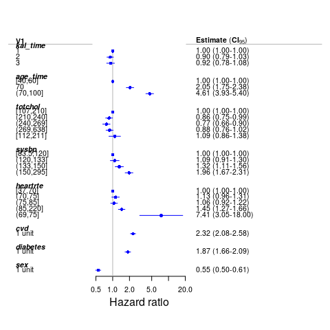

```r
plot(regressionTable(fit_p),plot.log="x")
```